Olive MGK Nov, 2018 Udacity Data Analyst Nanodegree ========================================================

## Exploring and Summarizing White Wine Data with R

Project Overview: The dataset contains white variants of the Portuguese “Vinho Verde” wine. There are 4898 white wine instances, 11 + output number of Attributes.

## Univariate Plots Section - and Preliminary exploration

```
## 'data.frame':    4898 obs. of  13 variables:
##  $ X                   : int  1 2 3 4 5 6 7 8 9 10 ...
##  $ fixed.acidity       : num  7 6.3 8.1 7.2 7.2 8.1 6.2 7 6.3 8.1 ...
##  $ volatile.acidity    : num  0.27 0.3 0.28 0.23 0.23 0.28 0.32 0.27 0.3 0.22 ...
##  $ citric.acid         : num  0.36 0.34 0.4 0.32 0.32 0.4 0.16 0.36 0.34 0.43 ...
##  $ residual.sugar      : num  20.7 1.6 6.9 8.5 8.5 6.9 7 20.7 1.6 1.5 ...
##  $ chlorides           : num  0.045 0.049 0.05 0.058 0.058 0.05 0.045 0.045 0.049 0.044 ...
##  $ free.sulfur.dioxide : num  45 14 30 47 47 30 30 45 14 28 ...
##  $ total.sulfur.dioxide: num  170 132 97 186 186 97 136 170 132 129 ...
##  $ density             : num  1.001 0.994 0.995 0.996 0.996 ...
##  $ pH                  : num  3 3.3 3.26 3.19 3.19 3.26 3.18 3 3.3 3.22 ...
##  $ sulphates           : num  0.45 0.49 0.44 0.4 0.4 0.44 0.47 0.45 0.49 0.45 ...
##  $ alcohol             : num  8.8 9.5 10.1 9.9 9.9 10.1 9.6 8.8 9.5 11 ...
##  $ quality             : int  6 6 6 6 6 6 6 6 6 6 ...
```

```
## [1] ""
```

```
##        X        fixed.acidity    volatile.acidity  citric.acid
##  Min.   :   1   Min.   : 3.800   Min.   :0.0800   Min.   :0.0000
##  1st Qu.:1225   1st Qu.: 6.300   1st Qu.:0.2100   1st Qu.:0.2700
##  Median :2450   Median : 6.800   Median :0.2600   Median :0.3200
##  Mean   :2450   Mean   : 6.855   Mean   :0.2782   Mean   :0.3342
##  3rd Qu.:3674   3rd Qu.: 7.300   3rd Qu.:0.3200   3rd Qu.:0.3900
##  Max.   :4898   Max.   :14.200   Max.   :1.1000   Max.   :1.6600
##  residual.sugar     chlorides       free.sulfur.dioxide
##  Min.   : 0.600   Min.   :0.00900   Min.   :  2.00
##  1st Qu.: 1.700   1st Qu.:0.03600   1st Qu.: 23.00
##  Median : 5.200   Median :0.04300   Median : 34.00
##  Mean   : 6.391   Mean   :0.04577   Mean   : 35.31
##  3rd Qu.: 9.900   3rd Qu.:0.05000   3rd Qu.: 46.00
##  Max.   :65.800   Max.   :0.34600   Max.   :289.00
##  total.sulfur.dioxide    density             pH          sulphates
##  Min.   :  9.0        Min.   :0.9871   Min.   :2.720   Min.   :0.2200
##  1st Qu.:108.0        1st Qu.:0.9917   1st Qu.:3.090   1st Qu.:0.4100
##  Median :134.0        Median :0.9937   Median :3.180   Median :0.4700
##  Mean   :138.4        Mean   :0.9940   Mean   :3.188   Mean   :0.4898
##  3rd Qu.:167.0        3rd Qu.:0.9961   3rd Qu.:3.280   3rd Qu.:0.5500
##  Max.   :440.0        Max.   :1.0390   Max.   :3.820   Max.   :1.0800
##     alcohol         quality
##  Min.   : 8.00   Min.   :3.000
##  1st Qu.: 9.50   1st Qu.:5.000
##  Median :10.40   Median :6.000
##  Mean   :10.51   Mean   :5.878
##  3rd Qu.:11.40   3rd Qu.:6.000
##  Max.   :14.20   Max.   :9.000
```

MyData has 4898 observations and 13 variables. 11 of these varibles are numeric with 2 being integers.

Confirms that MyData has no missing values.

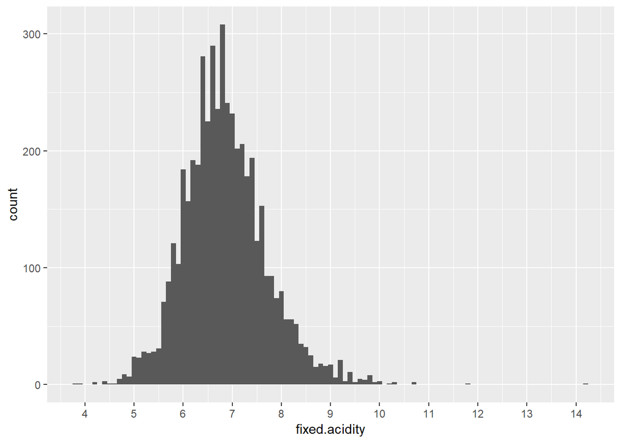

Fixed acidity is normally distributed at 6.8 g/dm^3 with some outliers.

```
##    Min. 1st Qu.  Median    Mean 3rd Qu.    Max.
##   3.800   6.300   6.800   6.855   7.300  14.200
```

Fixed acidity has a normal distribution centred about 6.9. The histogram shows that most white wines have an acidity ranging between 5.5 and 8.5.

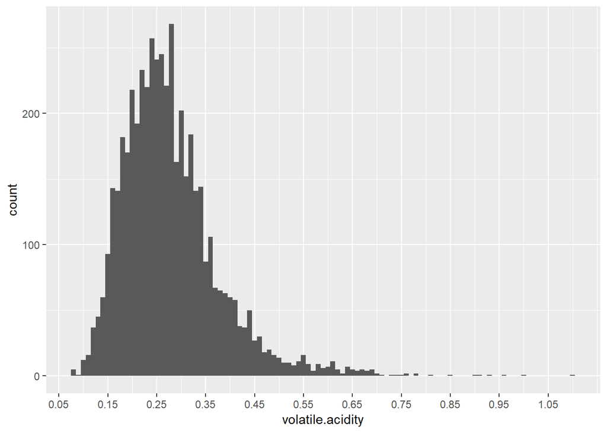

Volatile acidity has a distribution slightly skewed to the right, with a centre of 0.26. Most Wines have a VA between 0.15 and 0.35

```
##    Min. 1st Qu.  Median    Mean 3rd Qu.    Max.
##  0.0800  0.2100  0.2600  0.2782  0.3200  1.1000
```

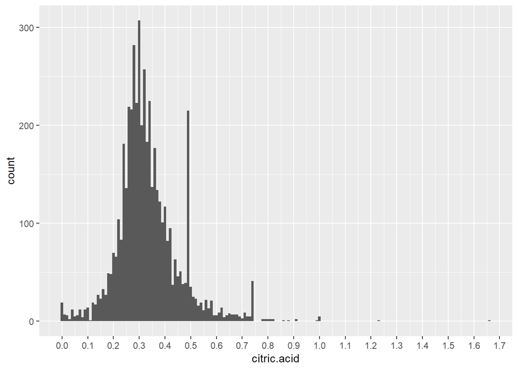

```
##    Min. 1st Qu.  Median    Mean 3rd Qu.    Max.
##  0.0000  0.2700  0.3200  0.3342  0.3900  1.6600
```

Citric acid is normally distributed with most wines ranging between 0.2 to 0.5.  
Some very notable Outliers at 0.49 and 0.75.

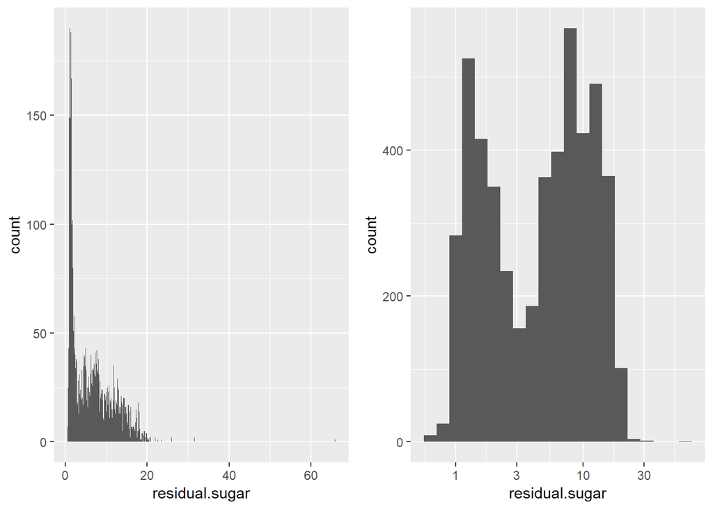

```
##    Min. 1st Qu.  Median    Mean 3rd Qu.    Max.
##   0.600   1.700   5.200   6.391   9.900  65.800
```

Residual sugar data is skewed to the right with the centre at 5.2g/dm^3 . To see the distribution better we transform the data using Log 10 scale. This gives a bimodal distribution. The max sugar can be 65 but most wines have a value less than 15. Note the outlier near zero.

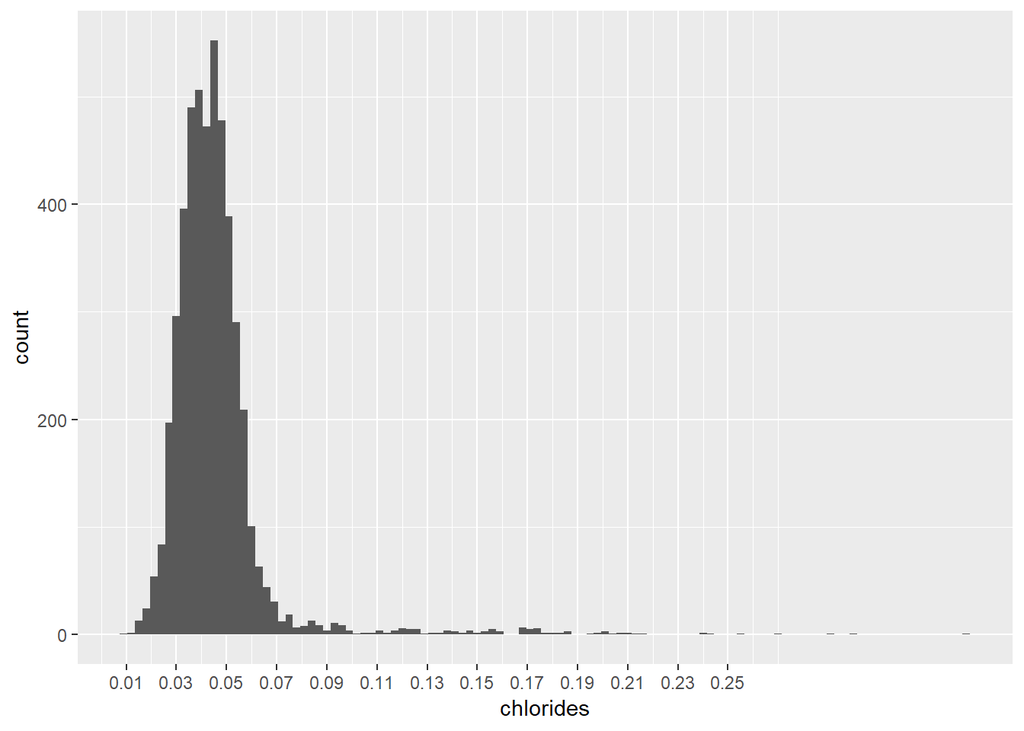

Chlorides have a normal distribution with a slight skew to the right. The centre is at 0.04300. Most wines fall between 0.025 - 0.065 mg/dm^3.

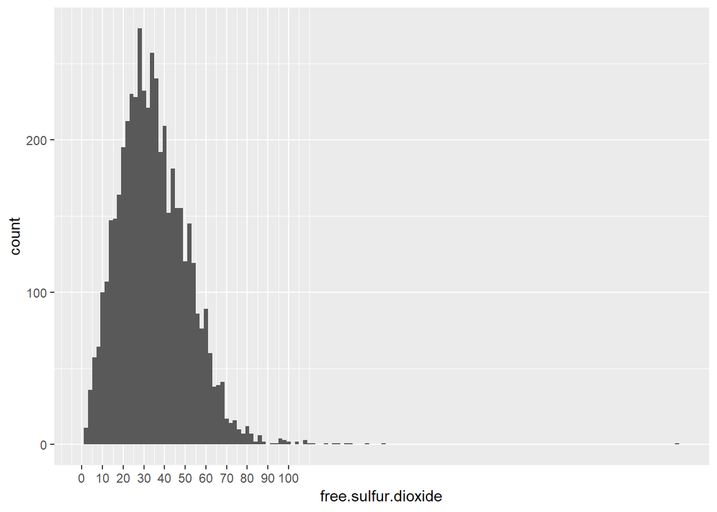

Free sulphur dioxide has a slight skew to the right with the centre being at 34.  
Most wines have a quantity less than 65 mg/dm^3.

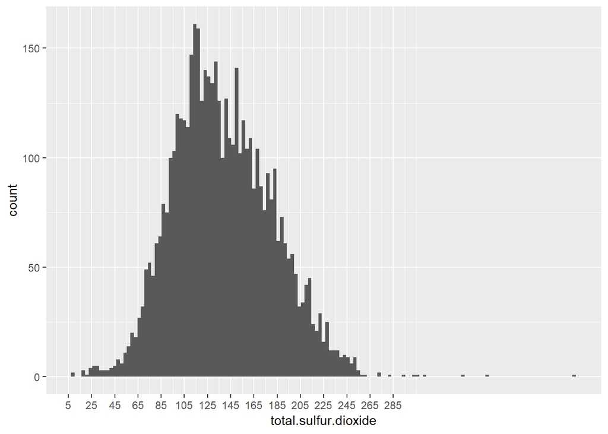

Total sulphur dioxide is normally distributed with a slight skew to the right. Most wines have a total between 65 and 215 mg/dm^3. The centre is at 134mg/dm^3.

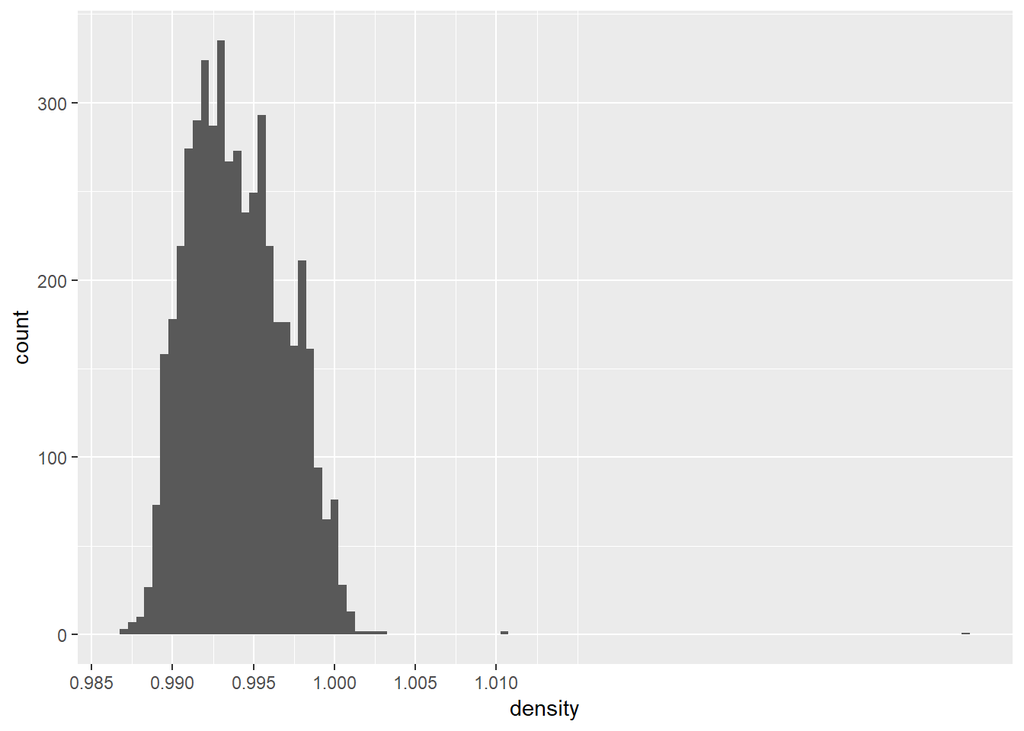

Density is normally distributed with a centre of 0.9940. Most wines have a denstity between 0.9855 and 1.000. There some notable outliers.

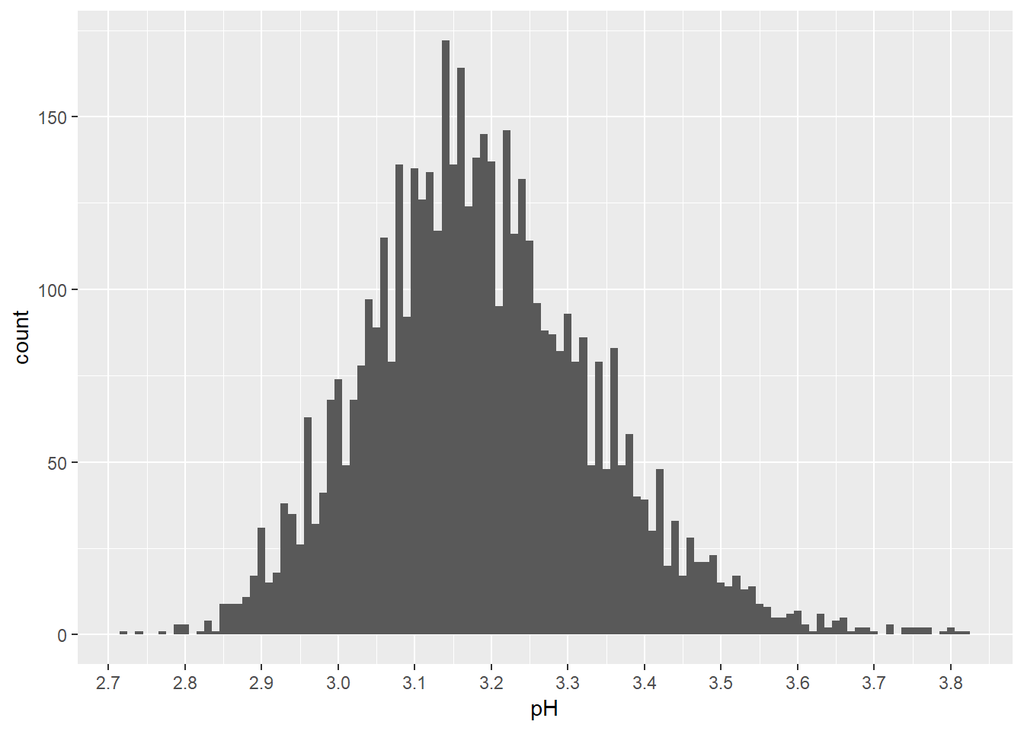

PH is symetric, With most wines ranging between 3.05 and 3.35. The mean is at 3.188. This shows that most wines have a pH below 4 due to fermentation.

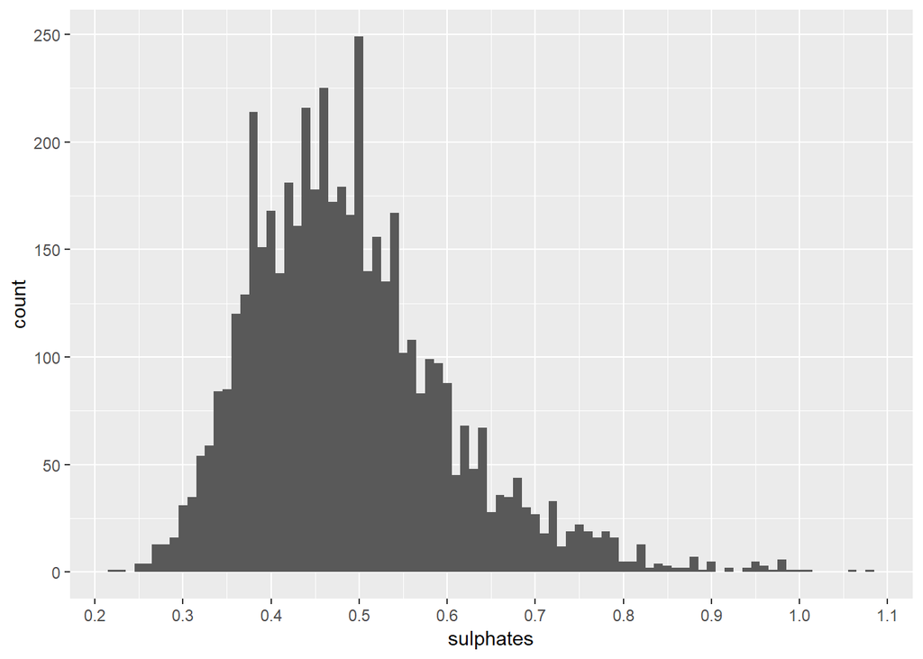

The distribution is slightly skewed to the right, the centre being at 0.47.  
Notable outliers at 0.36 and 0.5. Most wines range between 0.35 - 0.6

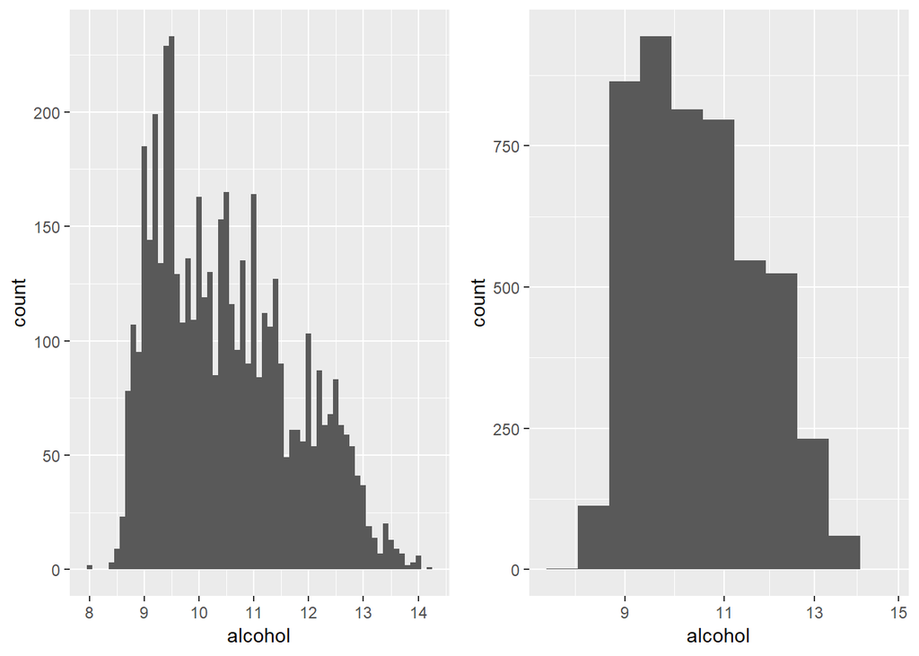

There is a wide range in the alchol content of wines between 8.5 - 14 % by volume. Alcohol data has a bimodal distribution that seems to be skewed to the right with a major peak at 9.5. The centre is at 10.40

```
## [1] TRUE
```

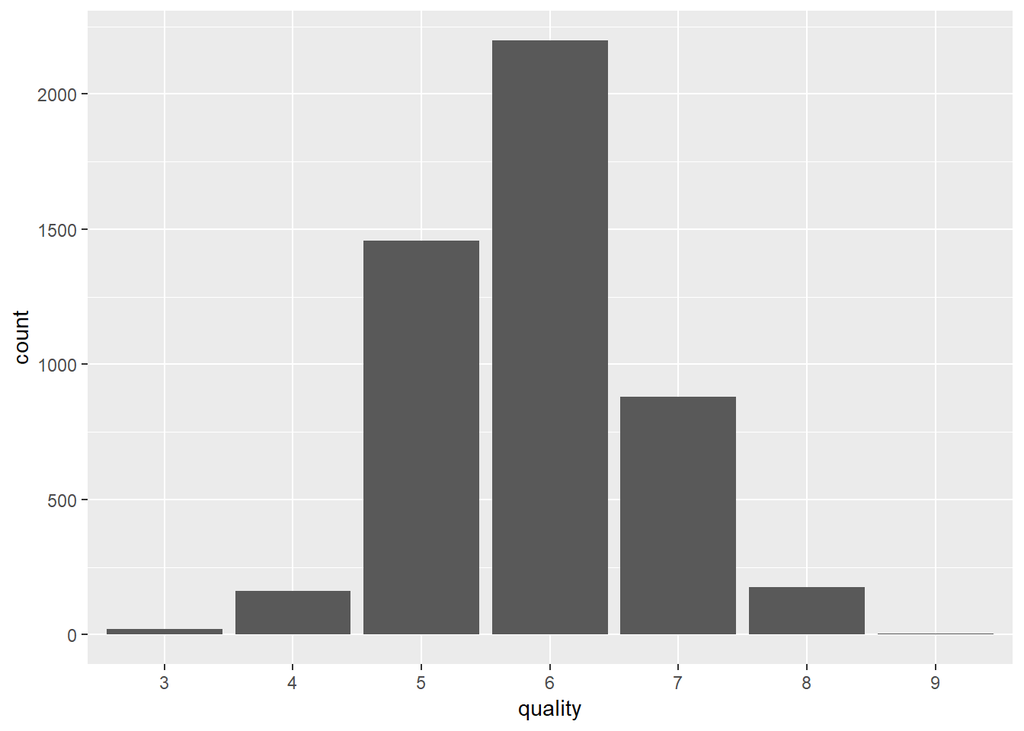

```
##
##    3    4    5    6    7    8    9
##   20  163 1457 2198  880  175    5
```

Majority of the wines are normal(5 - 7) than poor (3-4) or excellent one(8-9).

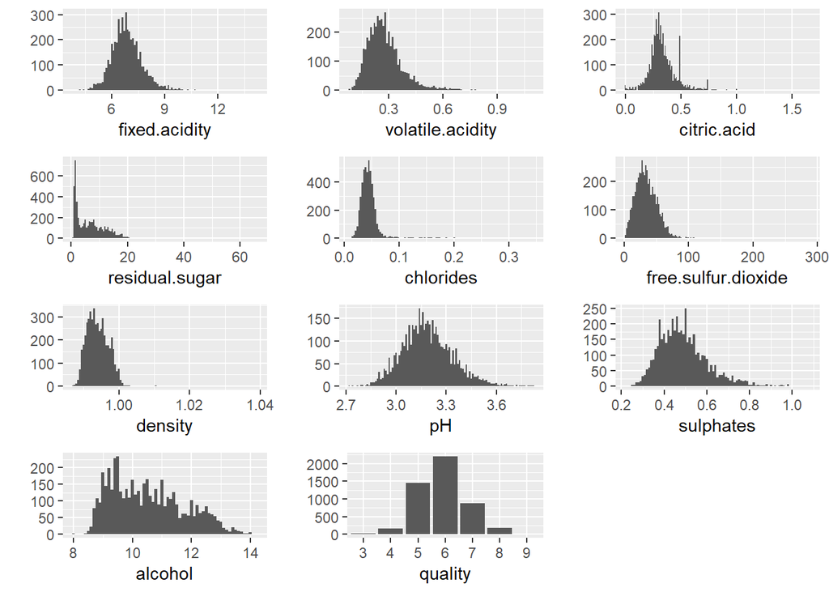

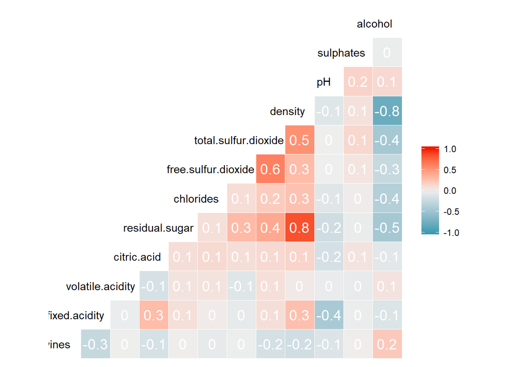

### Observations:

The pairs showing a correlation of 0.3 and above(in red) are likely to have a significant effect on the quality of wine and shall be the subject of our investigation. Such are pairs are: -fixed acidity & citric acid (0.3), -residual sugar & free.sulphurdioxide(0.3), -residual sugar & total.sulphurdioxide(0.4), -residual sugar & density(0.8) -chlorides & density(0.3)

### Univariate Analysis

#### What is the structure of your dataset?

The dataset - MyData has 4898 white wines(observations) with 13 features (variables). The column names of these variables are: fixed.acidity, volatile.acidity, citric.acid, residual.sugar, chlorides, free.sulfur.dioxide, total.sulfur.dioxide, density, pH, sulphates, alcohol, and quality

#### What is/are the main feature(s) of interest in your dataset?

The main features of interest are quality, residual sugar, alcohol and acids - which I think play the biggest role in the quality of wine. The objective of the analysis is to determine what features influence wine quality the most; then a predictive model of quality using these variables will be built.

#### Did you create any new variables from existing variables in the dataset?

No, variables were created in this case. Quality which was a numeric variable was converted into a factor.

#### Of the features you investigated, were there any unusual distributions? Did you perform any operations on the data to tidy, adjust, or change the form of the data? If so, why did you do this?

Residual.sugar and alcohol are noted for having unusual distributions and outliers. Residual sugar has a long right tail meaning the data is skewed greatly by outliers - this was then transformed in order to visualise the data better. The alcohol distribution has a bimodal shape with a slight skew to the right.

### Bivariate Plots Section

Features of interest are: -fixed acidity & citric acid (0.3), -residual sugar & free.sulphurdioxide(0.3), -residual sugar & total.sulphurdioxide(0.4), -residual sugar & density(0.8) -chlorides & density(0.3)

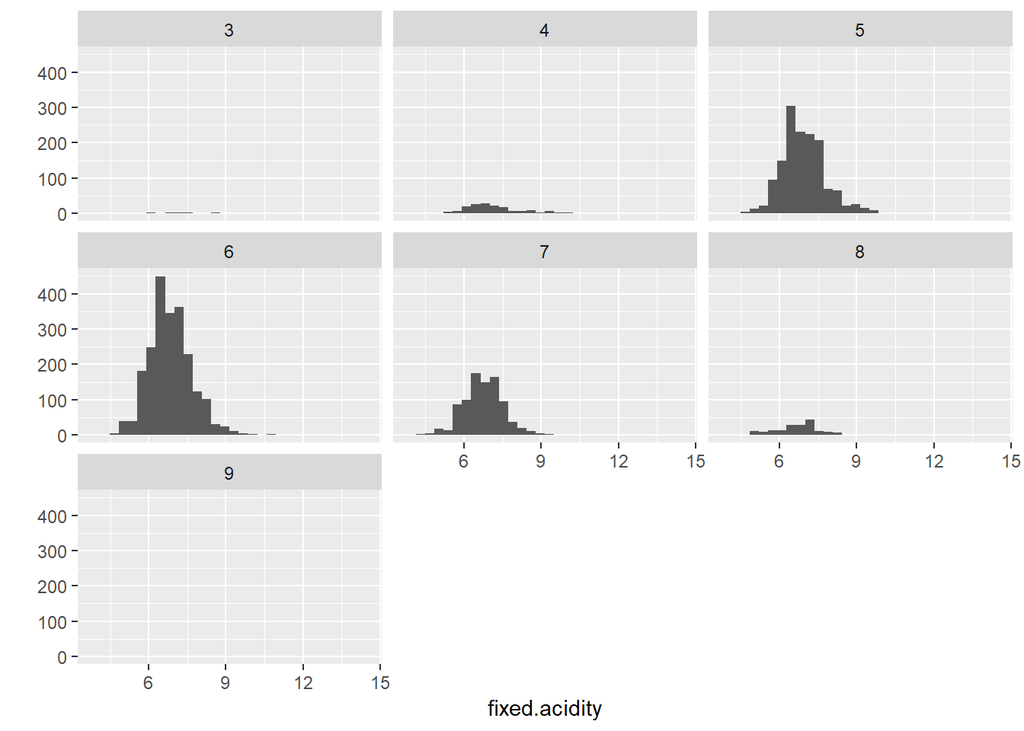

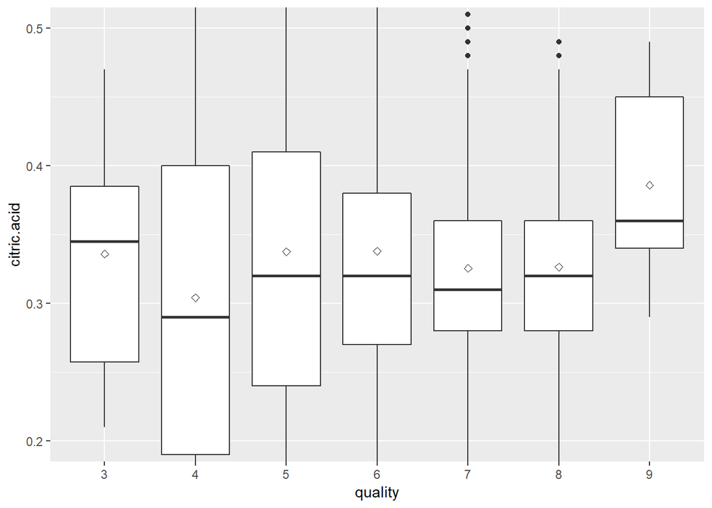

```
## MyData$quality: 3
##    Min. 1st Qu.  Median    Mean 3rd Qu.    Max.
##  0.2100  0.2575  0.3450  0.3360  0.3850  0.4700
## --------------------------------------------------------
## MyData$quality: 4
##    Min. 1st Qu.  Median    Mean 3rd Qu.    Max.
##  0.0000  0.1900  0.2900  0.3042  0.4000  0.8800
## --------------------------------------------------------
## MyData$quality: 5
##    Min. 1st Qu.  Median    Mean 3rd Qu.    Max.
##  0.0000  0.2400  0.3200  0.3377  0.4100  1.0000
## --------------------------------------------------------
## MyData$quality: 6
##    Min. 1st Qu.  Median    Mean 3rd Qu.    Max.
##   0.000   0.270   0.320   0.338   0.380   1.660
## --------------------------------------------------------
## MyData$quality: 7
##    Min. 1st Qu.  Median    Mean 3rd Qu.    Max.
##  0.0100  0.2800  0.3100  0.3256  0.3600  0.7400
## --------------------------------------------------------
## MyData$quality: 8
##    Min. 1st Qu.  Median    Mean 3rd Qu.    Max.
##  0.0400  0.2800  0.3200  0.3265  0.3600  0.7400
## --------------------------------------------------------
## MyData$quality: 9
##    Min. 1st Qu.  Median    Mean 3rd Qu.    Max.
##   0.290   0.340   0.360   0.386   0.450   0.490
```

Increase in citric acid to a value of 0.36 favored the quality of wine

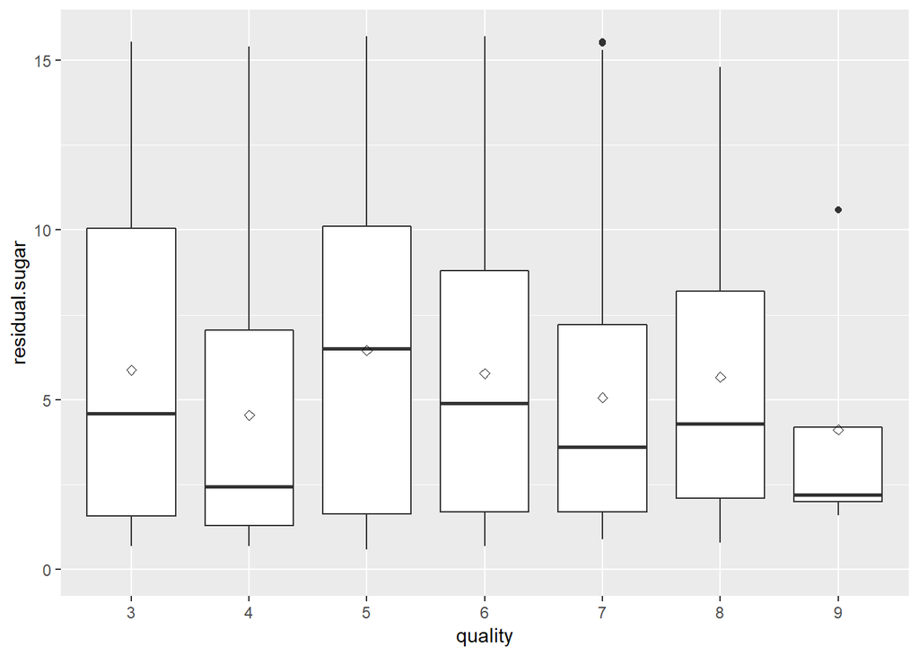

Apart from 5, the mean is pulled to the right by the outliers. There appears no clear trend of quality with residual sugar!

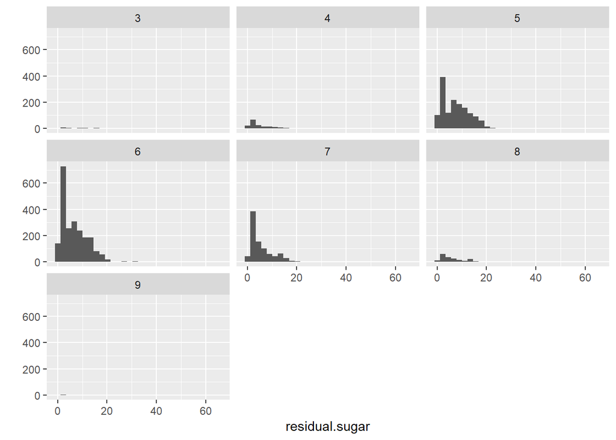

There is more sugar in 5, 6 and 7 and that could be partly the reason for their popularity but this same reason could account for why they’re not the best quality.

```
## MyData$quality: 3
##    Min. 1st Qu.  Median    Mean 3rd Qu.    Max.
##   0.700   1.587   4.600   6.393  10.700  16.200
## --------------------------------------------------------
## MyData$quality: 4
##    Min. 1st Qu.  Median    Mean 3rd Qu.    Max.
##   0.700   1.300   2.500   4.628   7.100  17.550
## --------------------------------------------------------
## MyData$quality: 5
##    Min. 1st Qu.  Median    Mean 3rd Qu.    Max.
##   0.600   1.800   7.000   7.335  11.500  23.500
## --------------------------------------------------------
## MyData$quality: 6
##    Min. 1st Qu.  Median    Mean 3rd Qu.    Max.
##   0.700   1.700   5.300   6.442   9.900  65.800
## --------------------------------------------------------
## MyData$quality: 7
##    Min. 1st Qu.  Median    Mean 3rd Qu.    Max.
##   0.900   1.700   3.650   5.186   7.325  19.250
## --------------------------------------------------------
## MyData$quality: 8
##    Min. 1st Qu.  Median    Mean 3rd Qu.    Max.
##   0.800   2.100   4.300   5.671   8.200  14.800
## --------------------------------------------------------
## MyData$quality: 9
##    Min. 1st Qu.  Median    Mean 3rd Qu.    Max.
##    1.60    2.00    2.20    4.12    4.20   10.60
```

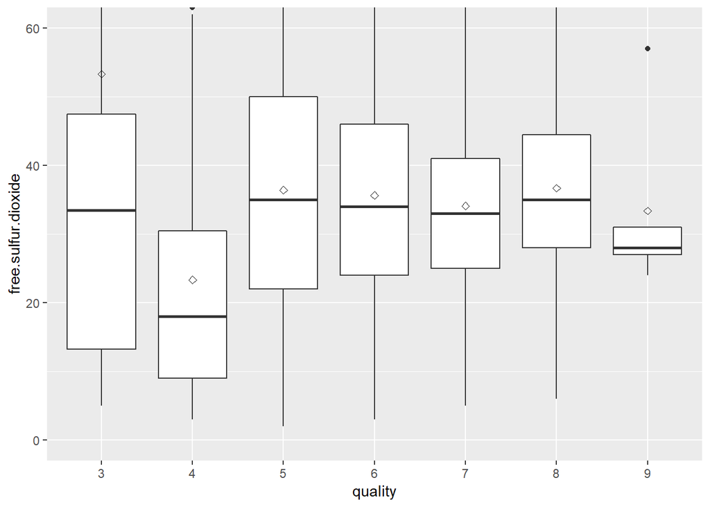

```
## MyData$quality: 3
##    Min. 1st Qu.  Median    Mean 3rd Qu.    Max.
##    5.00   13.25   33.50   53.33   47.50  289.00
## --------------------------------------------------------
## MyData$quality: 4
##    Min. 1st Qu.  Median    Mean 3rd Qu.    Max.
##    3.00    9.00   18.00   23.36   30.50  138.50
## --------------------------------------------------------
## MyData$quality: 5
##    Min. 1st Qu.  Median    Mean 3rd Qu.    Max.
##    2.00   22.00   35.00   36.43   50.00  131.00
## --------------------------------------------------------
## MyData$quality: 6
##    Min. 1st Qu.  Median    Mean 3rd Qu.    Max.
##    3.00   24.00   34.00   35.65   46.00  112.00
## --------------------------------------------------------
## MyData$quality: 7
##    Min. 1st Qu.  Median    Mean 3rd Qu.    Max.
##    5.00   25.00   33.00   34.13   41.00  108.00
## --------------------------------------------------------
## MyData$quality: 8
##    Min. 1st Qu.  Median    Mean 3rd Qu.    Max.
##    6.00   28.00   35.00   36.72   44.50  105.00
## --------------------------------------------------------
## MyData$quality: 9
##    Min. 1st Qu.  Median    Mean 3rd Qu.    Max.
##    24.0    27.0    28.0    33.4    31.0    57.0
```

A decrease in free suphurdioxide from 35 to about 28 mg / dm^3 improves the quality

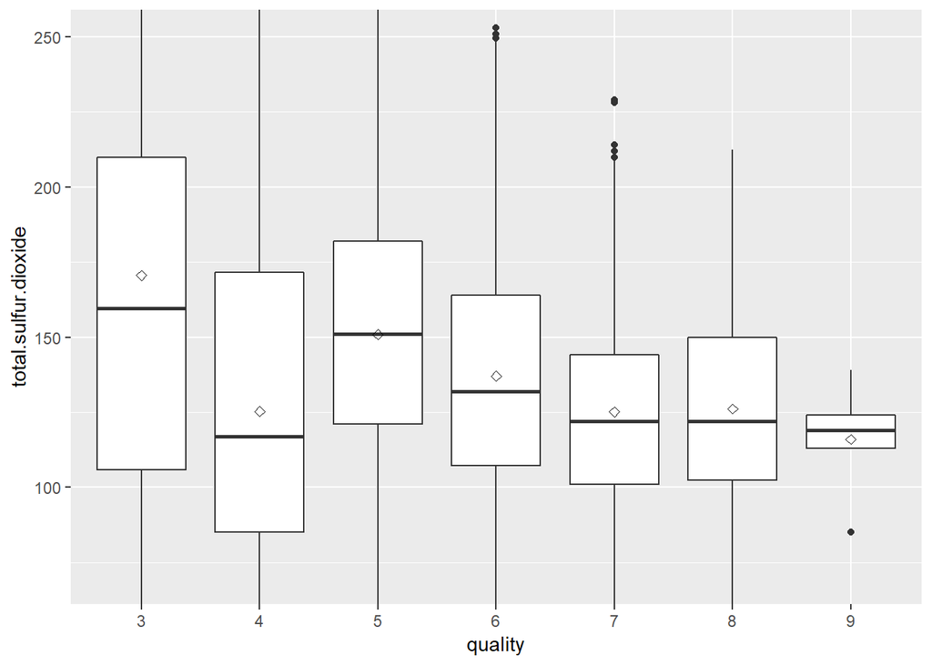

The trend shows that about 125 mg / dm^3 of total sulphur dioxide are optimum for quality. Let us get the exact values below.

```
## MyData$quality: 3
##    Min. 1st Qu.  Median    Mean 3rd Qu.    Max.
##    19.0   105.8   159.5   170.6   210.0   440.0
## --------------------------------------------------------
## MyData$quality: 4
##    Min. 1st Qu.  Median    Mean 3rd Qu.    Max.
##    10.0    85.0   117.0   125.3   171.5   272.0
## --------------------------------------------------------
## MyData$quality: 5
##    Min. 1st Qu.  Median    Mean 3rd Qu.    Max.
##     9.0   121.0   151.0   150.9   182.0   344.0
## --------------------------------------------------------
## MyData$quality: 6
##    Min. 1st Qu.  Median    Mean 3rd Qu.    Max.
##    18.0   107.2   132.0   137.0   164.0   294.0
## --------------------------------------------------------
## MyData$quality: 7
##    Min. 1st Qu.  Median    Mean 3rd Qu.    Max.
##    34.0   101.0   122.0   125.1   144.2   229.0
## --------------------------------------------------------
## MyData$quality: 8
##    Min. 1st Qu.  Median    Mean 3rd Qu.    Max.
##    59.0   102.5   122.0   126.2   150.0   212.5
## --------------------------------------------------------
## MyData$quality: 9
##    Min. 1st Qu.  Median    Mean 3rd Qu.    Max.
##      85     113     119     116     124     139
```

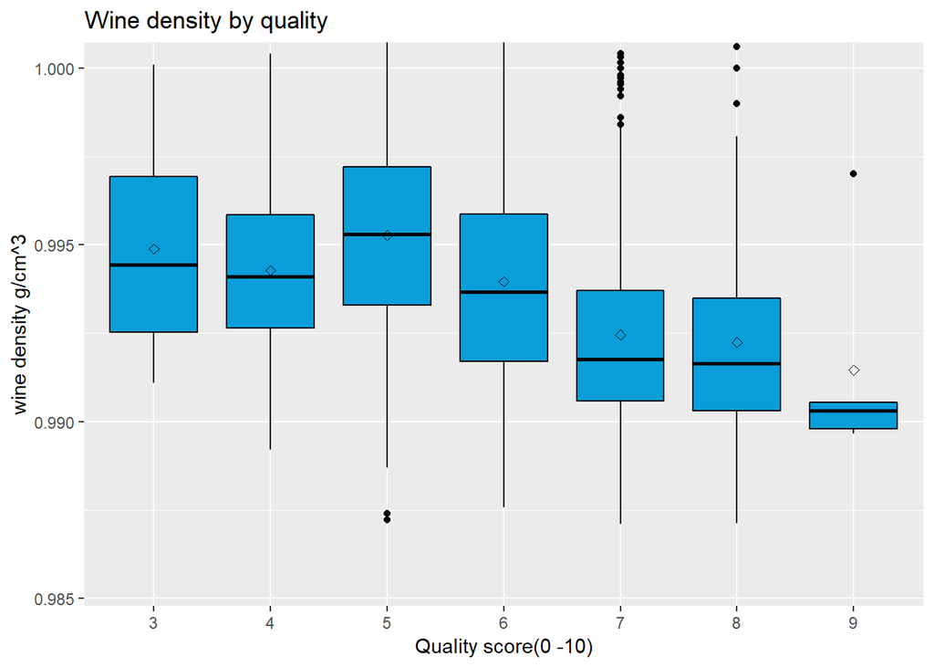

```
## MyData$quality: 3
##    Min. 1st Qu.  Median    Mean 3rd Qu.    Max.
##  0.9911  0.9925  0.9944  0.9949  0.9969  1.0001
## --------------------------------------------------------
## MyData$quality: 4
##    Min. 1st Qu.  Median    Mean 3rd Qu.    Max.
##  0.9892  0.9926  0.9941  0.9943  0.9958  1.0004
## --------------------------------------------------------
## MyData$quality: 5
##    Min. 1st Qu.  Median    Mean 3rd Qu.    Max.
##  0.9872  0.9933  0.9953  0.9953  0.9972  1.0024
## --------------------------------------------------------
## MyData$quality: 6
##    Min. 1st Qu.  Median    Mean 3rd Qu.    Max.
##  0.9876  0.9917  0.9937  0.9940  0.9959  1.0390
## --------------------------------------------------------
## MyData$quality: 7
##    Min. 1st Qu.  Median    Mean 3rd Qu.    Max.
##  0.9871  0.9906  0.9918  0.9925  0.9937  1.0004
## --------------------------------------------------------
## MyData$quality: 8
##    Min. 1st Qu.  Median    Mean 3rd Qu.    Max.
##  0.9871  0.9903  0.9916  0.9922  0.9935  1.0006
## --------------------------------------------------------
## MyData$quality: 9
##    Min. 1st Qu.  Median    Mean 3rd Qu.    Max.
##  0.9897  0.9898  0.9903  0.9915  0.9906  0.9970
```

The trend from 5 - 9 seems to show that lowering density values(from 0.9953  
to 0.9903) seems to improve wine quality

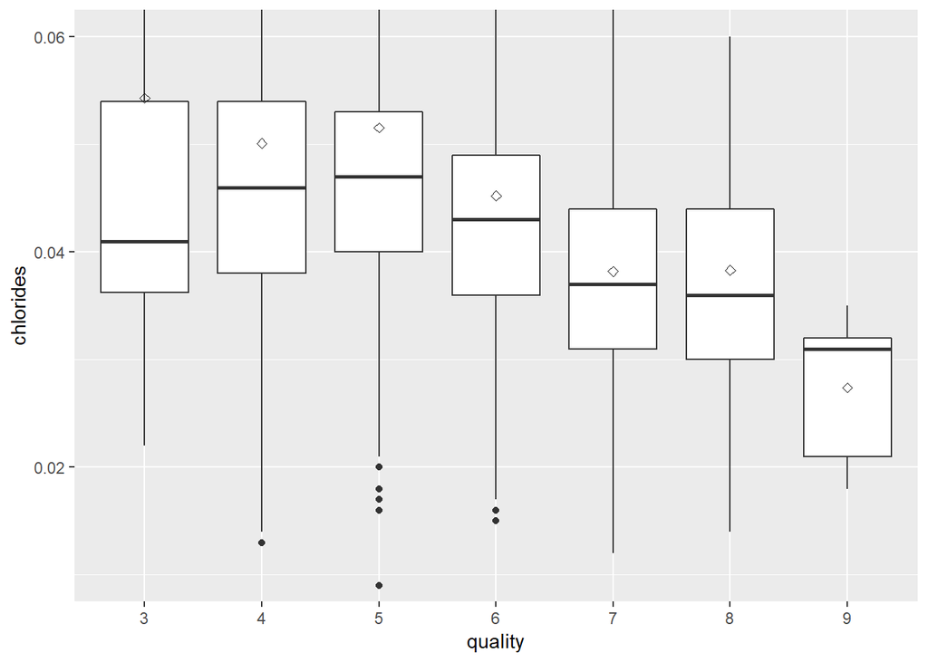

Lowering chloride levels from 0.046 to 0.031 improves the quality of wine

```
## MyData$quality: 3
##    Min. 1st Qu.  Median    Mean 3rd Qu.    Max.
## 0.02200 0.03625 0.04100 0.05430 0.05400 0.24400
## --------------------------------------------------------
## MyData$quality: 4
##    Min. 1st Qu.  Median    Mean 3rd Qu.    Max.
##  0.0130  0.0380  0.0460  0.0501  0.0540  0.2900
## --------------------------------------------------------
## MyData$quality: 5
##    Min. 1st Qu.  Median    Mean 3rd Qu.    Max.
## 0.00900 0.04000 0.04700 0.05155 0.05300 0.34600
## --------------------------------------------------------
## MyData$quality: 6
##    Min. 1st Qu.  Median    Mean 3rd Qu.    Max.
## 0.01500 0.03600 0.04300 0.04522 0.04900 0.25500
## --------------------------------------------------------
## MyData$quality: 7
##    Min. 1st Qu.  Median    Mean 3rd Qu.    Max.
## 0.01200 0.03100 0.03700 0.03819 0.04400 0.13500
## --------------------------------------------------------
## MyData$quality: 8
##    Min. 1st Qu.  Median    Mean 3rd Qu.    Max.
## 0.01400 0.03000 0.03600 0.03831 0.04400 0.12100
## --------------------------------------------------------
## MyData$quality: 9
##    Min. 1st Qu.  Median    Mean 3rd Qu.    Max.
##  0.0180  0.0210  0.0310  0.0274  0.0320  0.0350
```

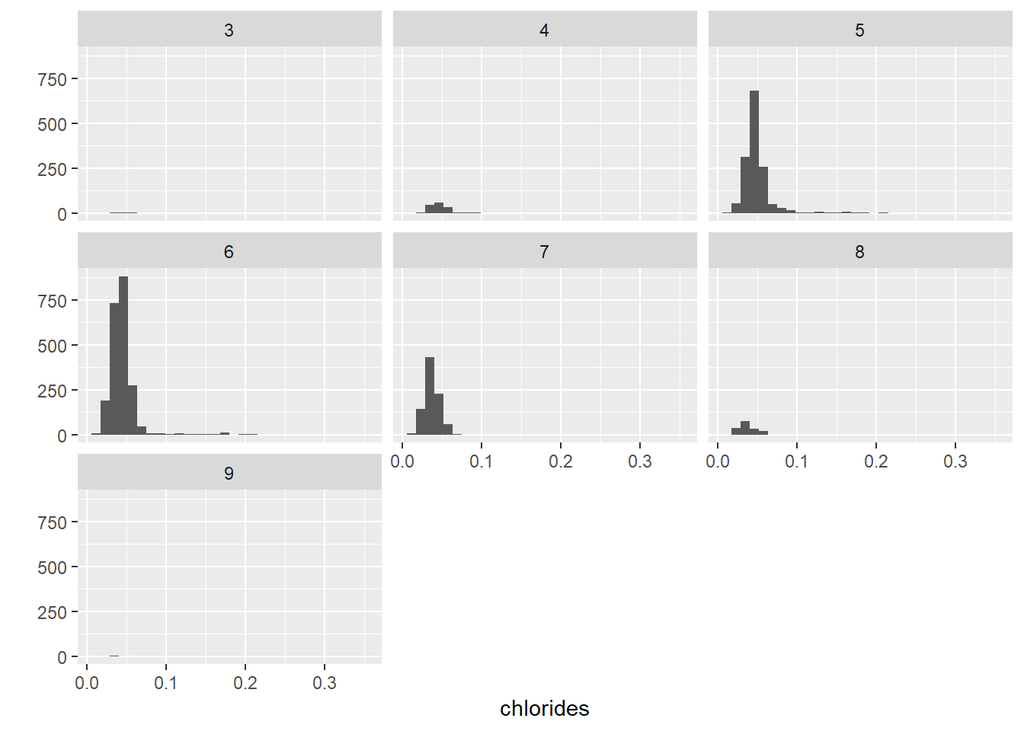

The trend from a quality of 5 - 9 seems to show that lowering chloride values from 0.04700 to 0.0310 g / dm^3 seems to improve wine quality

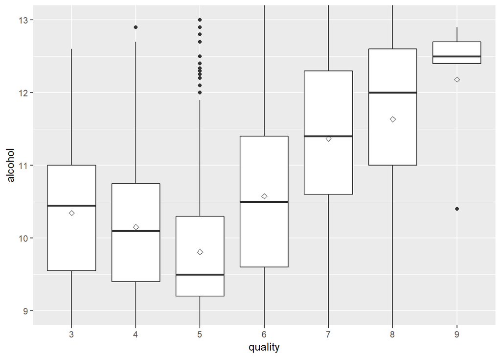

Increase in alcohol content is in line with increased quality of wine

```
## MyData$quality: 3
##    Min. 1st Qu.  Median    Mean 3rd Qu.    Max.
##    8.00    9.55   10.45   10.35   11.00   12.60
## --------------------------------------------------------
## MyData$quality: 4
##    Min. 1st Qu.  Median    Mean 3rd Qu.    Max.
##    8.40    9.40   10.10   10.15   10.75   13.50
## --------------------------------------------------------
## MyData$quality: 5
##    Min. 1st Qu.  Median    Mean 3rd Qu.    Max.
##   8.000   9.200   9.500   9.809  10.300  13.600
## --------------------------------------------------------
## MyData$quality: 6
##    Min. 1st Qu.  Median    Mean 3rd Qu.    Max.
##    8.50    9.60   10.50   10.58   11.40   14.00
## --------------------------------------------------------
## MyData$quality: 7
##    Min. 1st Qu.  Median    Mean 3rd Qu.    Max.
##    8.60   10.60   11.40   11.37   12.30   14.20
## --------------------------------------------------------
## MyData$quality: 8
##    Min. 1st Qu.  Median    Mean 3rd Qu.    Max.
##    8.50   11.00   12.00   11.64   12.60   14.00
## --------------------------------------------------------
## MyData$quality: 9
##    Min. 1st Qu.  Median    Mean 3rd Qu.    Max.
##   10.40   12.40   12.50   12.18   12.70   12.90
```

The values support the visualisation above

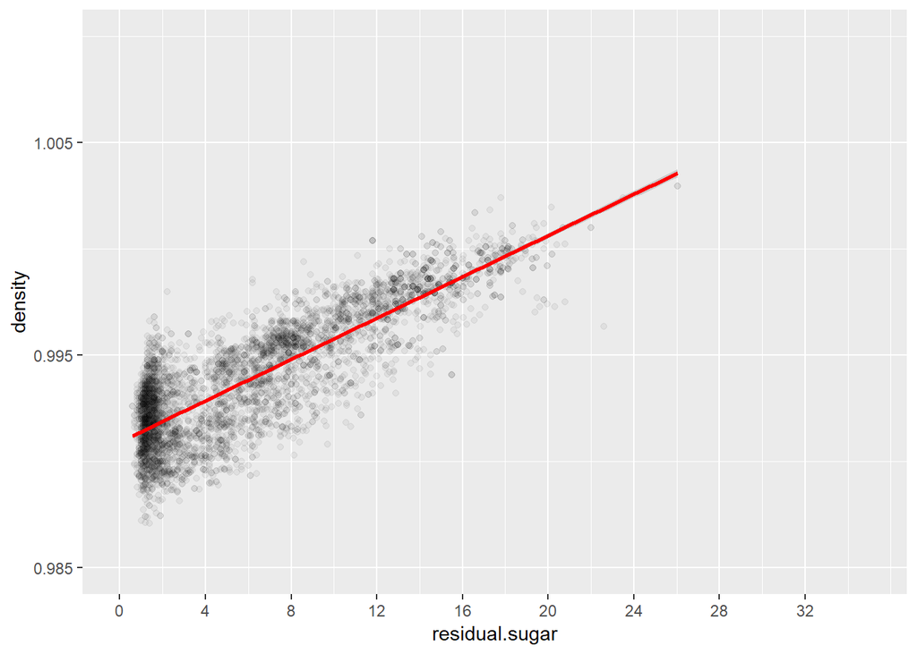

Density increases with increased sugar; the two variables are highly positively correlated at 0.84

```
##
##  Pearson's product-moment correlation
##
## data:  MyData$density and MyData$residual.sugar
## t = 107.87, df = 4896, p-value < 2.2e-16
## alternative hypothesis: true correlation is not equal to 0
## 95 percent confidence interval:
##  0.8304732 0.8470698
## sample estimates:
##       cor
## 0.8389665
```

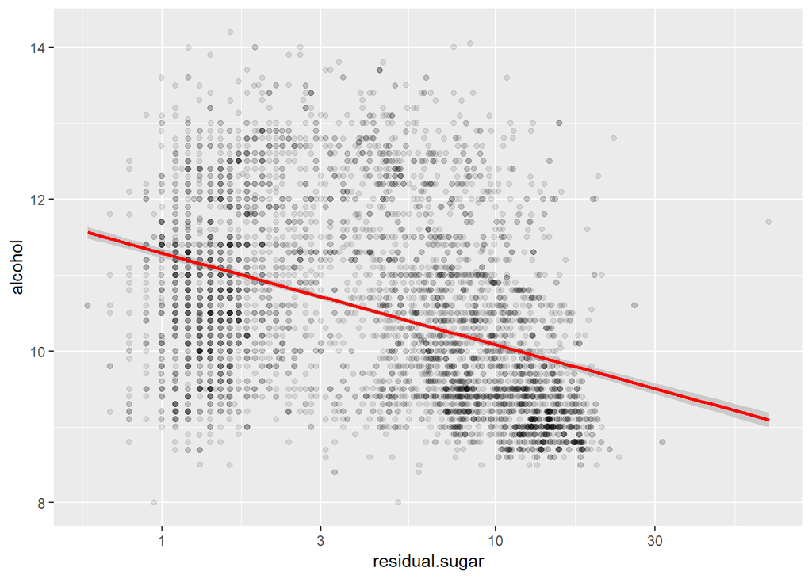

Increase in sugar does not lead to increase in alcohol.

```
##
##  Pearson's product-moment correlation
##
## data:  MyData$residual.sugar and MyData$alcohol
## t = -35.321, df = 4896, p-value < 2.2e-16
## alternative hypothesis: true correlation is not equal to 0
## 95 percent confidence interval:
##  -0.4726723 -0.4280267
## sample estimates:
##        cor
## -0.4506312
```

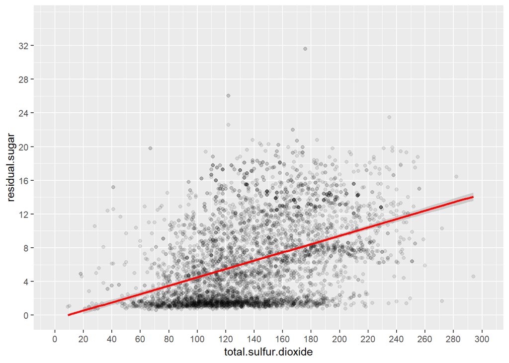

An increase in total sulphurdioxide shows an increase in sugar with a fairly strong correlation of 0.4. I wonder whether this a better determinant of wine quality!

```
##
##  Pearson's product-moment correlation
##
## data:  MyData$residual.sugar and MyData$total.sulfur.dioxide
## t = 30.669, df = 4896, p-value < 2.2e-16
## alternative hypothesis: true correlation is not equal to 0
## 95 percent confidence interval:
##  0.3776791 0.4246712
## sample estimates:
##       cor
## 0.4014393
```

## Bivariate Analysis

#### Talk about some of the relationships you observed.

How did the feature(s) of interest vary with other features in  
the dataset?  
The question being addressed here is how quality varied in relation to fixed acidity, residual sugar, free.sulphurdioxide, total.sulphurdioxide, density and chloride.

Fixed acidity and citric acid show a ‘U-like’ pattern! starting from a high value of 0.345g/dm^3 with quality 3, the citric acid is lowered to 0.32 and gradually increased to 0.36 at quality level 9. The increase shows an in the quality.

Residual sugar - is sugar left over after fermentation. There is no clear trend here. However Sugar content decreases from 7 at quality 5 to 2.2 g/dm^3 at 9. This is telling us that the best quality wine has less sugar.  
But again it depends on ones taste because quality 8 has a sugar level twice as much as that at nine.

Free Sulphur dioxide: The wine quality from 5 - 9 shows a trend from 35 to 28 mg/dm^3;showing that a decrease within this range improves quality. A similar trend is shown by the total sulphates since they both work as antioxidants and preservatives of wine.

Density: a decrease in density from 0.9953 to 0.9903 corresponds to a quality increase of 5 to 9. It makes sense since density results from a combination of alcohol and sugar. And we see that density changes correspond to the changes both in alcohol and sugar. This is confirmed by the high positive correlation of density and sugar of 0.84.

An increase in alcohol content supports increased wine quality from 5 - 9. While a decrease in the amount of chlorides which are essentially salts supports improved wine quality.

increase in alcohol improves quality. Note that the high correlation of residual sugar with density is due to the combination of both the residual sugar and alcohol.

#### What was the strongest relationship you found?

The strongest relationship is that of residual sugar and density which gives a positive correlation of 0.84.

## Multivariate Plots Section

I would like to establish whether its density or total sulphurdioxide vs residual sugar that can better show the differences in wine quality.

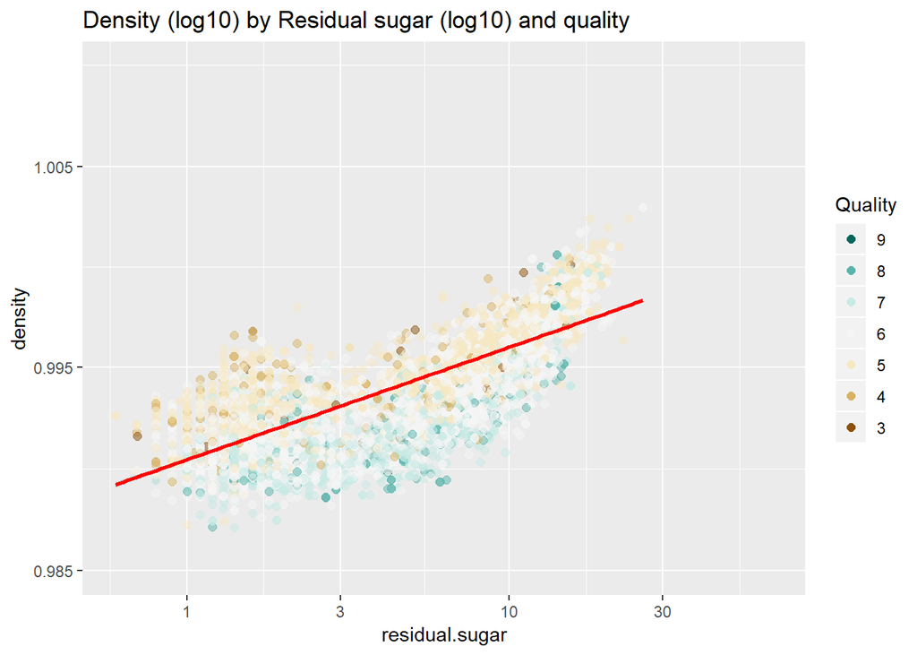

Interesting! - the red line clearly divides quality into 2 groups; we have wines of quality 3-5 clearly above the line. 6 seems to lie in the boundary while 7,8 and 9 are blow the line. Density & residual sugar dynamics are a good choice in determining wine quality. I think this can make a good model.

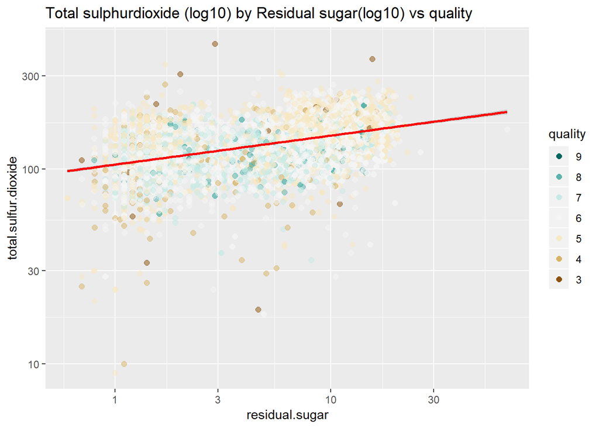

The demarcation between the qualities is not clear at all, therefore, I would not take this as a good model.

#### Building the linear model

To create a linear model I will use the lm function. Density is the outcome and residual sugar is the predictor variable. Note the use of the I Wrapper around each of the variables.

I can also update the previous model to add another factor in the regression (using the syntax below). We can continue to make more complex models by adding more variables (chlorides, free.sulphurdioxide, fixed acidity, residual sugar etc).

```
##
## Calls:
## m1: lm(formula = I(log(density)) ~ I(residual.sugar), data = MyData)
## m2: lm(formula = I(log(density)) ~ I(residual.sugar) + residual.sugar,
##     data = MyData)
## m3: lm(formula = I(log(density)) ~ I(residual.sugar) + residual.sugar +
##     total.sulfur.dioxide, data = MyData)
## m4: lm(formula = I(log(density)) ~ I(residual.sugar) + residual.sugar +
##     total.sulfur.dioxide + fixed.acidity, data = MyData)
## m5: lm(formula = I(log(density)) ~ I(residual.sugar) + residual.sugar +
##     total.sulfur.dioxide + fixed.acidity + chlorides, data = MyData)
## m6: lm(formula = I(log(density)) ~ I(residual.sugar) + residual.sugar +
##     total.sulfur.dioxide + fixed.acidity + chlorides + pH, data = MyData)
## m7: lm(formula = I(log(density)) ~ I(residual.sugar) + residual.sugar +
##     total.sulfur.dioxide + fixed.acidity + chlorides + pH + alcohol,
##     data = MyData)
## m8: lm(formula = I(log(density)) ~ I(residual.sugar) + residual.sugar +
##     total.sulfur.dioxide + fixed.acidity + chlorides + pH + alcohol +
##     sulphates, data = MyData)
## m9: lm(formula = I(log(density)) ~ I(residual.sugar) + residual.sugar +
##     total.sulfur.dioxide + fixed.acidity + chlorides + pH + alcohol +
##     sulphates + citric.acid, data = MyData)
##
## =================================================================================================================================================================================
##                               m1               m2               m3               m4               m5               m6               m7               m8               m9
## ---------------------------------------------------------------------------------------------------------------------------------------------------------------------------------
##   (Intercept)               -0.009***        -0.009***        -0.011***        -0.015***        -0.016***        -0.029***        -0.014***        -0.014***        -0.014***
##                             (0.000)          (0.000)          (0.000)          (0.000)          (0.000)          (0.001)          (0.000)          (0.000)          (0.000)
##   I(residual.sugar)          0.000***         0.000***         0.000***         0.000***         0.000***         0.000***         0.000***         0.000***         0.000***
##                             (0.000)          (0.000)          (0.000)          (0.000)          (0.000)          (0.000)          (0.000)          (0.000)          (0.000)
##   total.sulfur.dioxide                                         0.000***         0.000***         0.000***         0.000***         0.000***         0.000***         0.000***
##                                                               (0.000)          (0.000)          (0.000)          (0.000)          (0.000)          (0.000)          (0.000)
##   fixed.acidity                                                                 0.001***         0.001***         0.001***         0.001***         0.001***         0.001***
##                                                                                (0.000)          (0.000)          (0.000)          (0.000)          (0.000)          (0.000)
##   chlorides                                                                                      0.021***         0.023***         0.005***         0.005***         0.005***
##                                                                                                 (0.001)          (0.001)          (0.000)          (0.000)          (0.000)
##   pH                                                                                                              0.004***         0.004***         0.003***         0.003***
```

[output cut: 19 more lines]

so much information, so many values here - better to get a summarised output!

```
##
## Call:
## lm(formula = I(log(density)) ~ I(residual.sugar), data = MyData)
##
## Residuals:
##        Min         1Q     Median         3Q        Max
## -0.0057040 -0.0011095  0.0001773  0.0011594  0.0147202
##
## Coefficients:
##                     Estimate Std. Error t value Pr(>|t|)
## (Intercept)       -9.170e-03  3.762e-05  -243.7   <2e-16 ***
## I(residual.sugar)  4.968e-04  4.611e-06   107.7   <2e-16 ***
## ---
## Signif. codes:  0 '***' 0.001 '**' 0.01 '*' 0.05 '.' 0.1 ' ' 1
##
## Residual standard error: 0.001637 on 4896 degrees of freedom
## Multiple R-squared:  0.7033, Adjusted R-squared:  0.7033
## F-statistic: 1.161e+04 on 1 and 4896 DF,  p-value: < 2.2e-16
```

### Multivariate Analysis

#### Talk about some of the relationships you observed in this part of the investigation. Were there features that strengthened each other in terms of looking at your feature(s) of interest?

I investigated residual sugar vs density by quality and residual sugar vs total sulphurdioxide by quality . Of the two plots, residual sugar vs density by quality provided the best demarcation within the groups of quality.

#### Were there any interesting or surprising interactions between features?

The plot of residual sugar vs total sulphurdioxide seemed interesting with a strong correlation of 0.4 however when combined with quality I was surprised that it did not show any clear trend.

#### Strengths and limitations of your model.

The limitation is that it needs vast amounts of information and can not directly influence the process to give the desired outcome.

They can predict the quality of a wine vintage but won’t make the wine any better, reduce its acidity, improve the balance, or change the undertones. For these sorts of estimates, finding ways to avoid bias and maintain accuracy is essential.

### Final Plots and Summary

#### Plot One

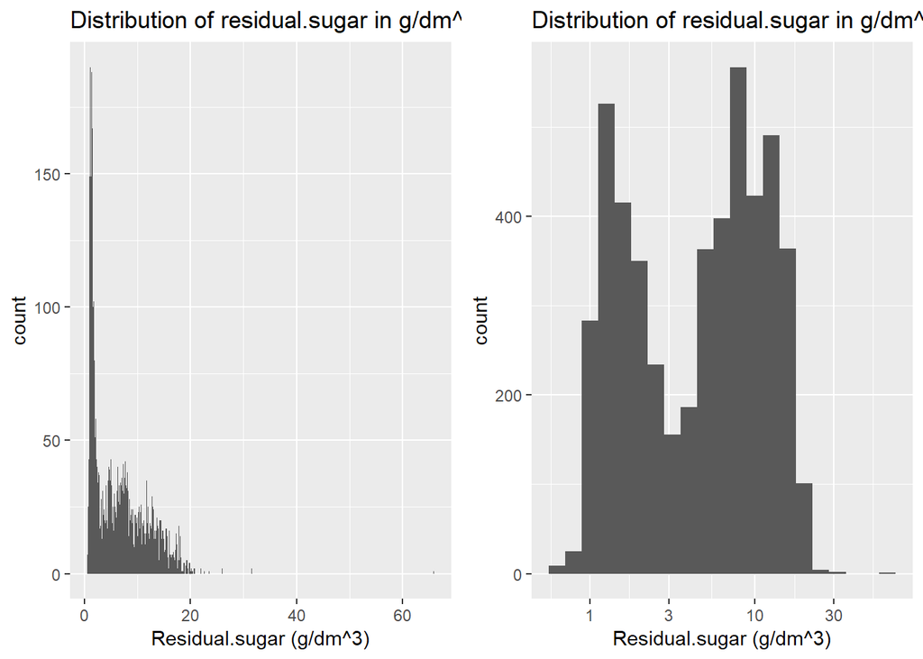

#### Description One

Residual sugar data is skewed to the right with the centre at 5.2g/dm^3. Note the outliers especially about zero . To see the distribution better, the data is transformed using Log 10 scale. This gives a bimodal distribution as shown. The max sugar can be 65 but most wines have a value less than 15. Note the outlier near zero.

#### Plot Two

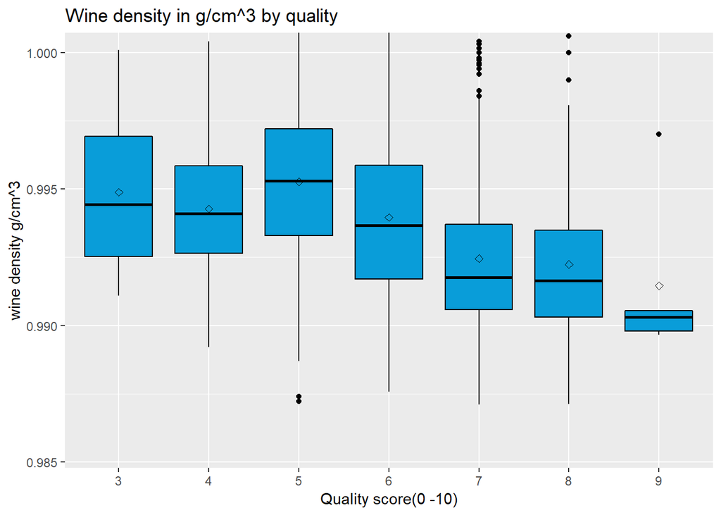

#### Description Two

This is an interesting plot becuase it shows that the density of all wines is almost the same. Secondly it demonstrates how small minor changes in density affect wine quality.

#### Plot Three

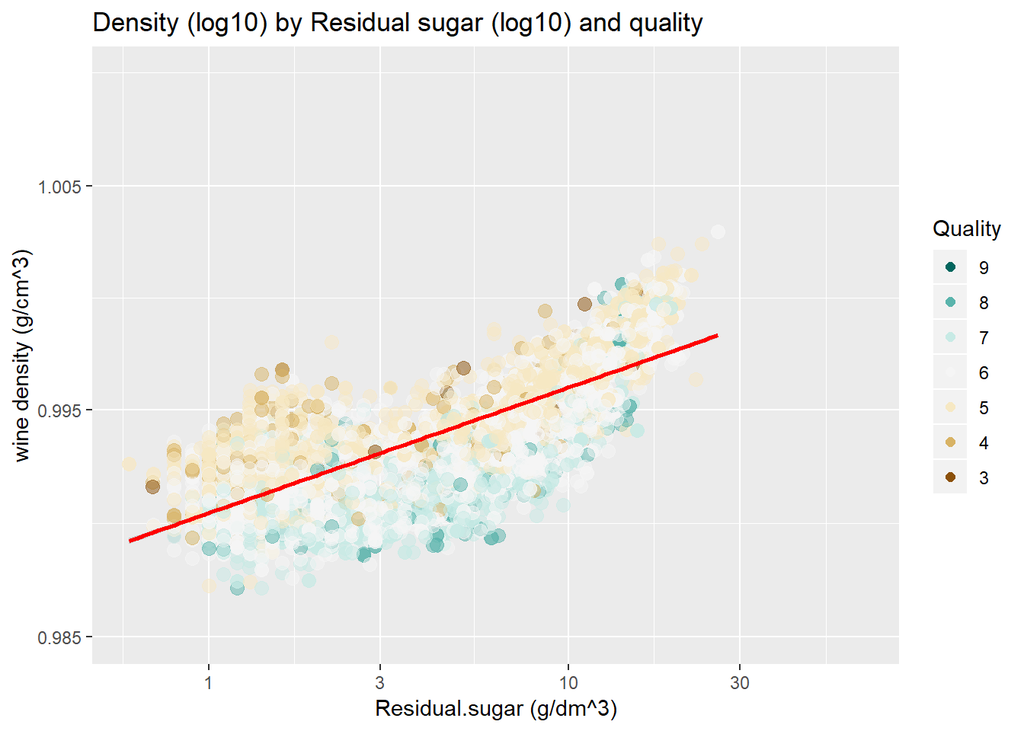

#### Description Three

This is an interesting plot! - the red line clearly divides quality into 2 groups; The plot clearly shows the less density fines have better quality than the denser ones above the line. Density & residual sugar dynamics are therefor a good choice in determining wine quality. I am confident that this makes a good model.

## Reflection

What a journey! Its great to come to a close, I have certainly been challenged and had fun too. I have had to reset my PC to factory standard twice to remove one drive and delet it from the path of my downloads. Debugging errors would sometimes take ages than was necessary. Other than that it was partly an easy trip because the dataset is clean and almost no data wrangling was  
necessary. Making the different plots, the adjustment, transformations and interpretion - has been a valuable experience.

The systematic exploration of the dataset from univariates to bivariates and finally multivariates helped me to progressively understand the dataset. Uncovering insights especially when relating two variables and more was interesting. Now I have a good understanding of how the different variables in wine interact with each other to produce wine. Its interesting to see how minor changes like with density or alchohol - can determine the quality of wine. Quality is subjective. Striking a good balance is key.

I believe that there is always room for improvement. This dataset can be made richer by adding external variables like soil type, variety of the grape, weather etc. With that said, Wine quality is definately a very subjective measure.  
While beauty depends on the eyes of the beholder, wine depends on the palate of the individual!